# SPO_seminar_Ivan_Modric

KOLEGIJ: Sustavi za podršku odlučivanju

Student: Ivan Modrić

Fakultet informatike i digitalnih tehnologija - Diplomski studij

Informacijski i komunikacijski sustavi; 2. semestar

Akademska godina 2021./2022.

Importanje pandasa.

```python
import pandas as pd
```

Učitavanje datasetova. Prvi prikazuje GDP po državama i godinama, a drugi postotak ljudi s tercijarnim obrazovanjem po drzavama, godinama i određenim grupama.

```python
podaci1 = pd.read_csv("gdp_per_capita.csv")
podaci2 = pd.read_csv("tertiary_education.csv")
```

Gledam kako datasetovi izgledaju da znam s čime uopće imam posla.

```python
podaci1.info()
```

```
<class 'pandas.core.frame.DataFrame'>
RangeIndex: 1681 entries, 0 to 1680
Data columns (total 9 columns):
 #   Column       Non-Null Count  Dtype
---  ------       --------------  -----
 0   DATAFLOW     1681 non-null   object
 1   LAST UPDATE  1681 non-null   object
 2   freq         1681 non-null   object
 3   unit         1681 non-null   object
 4   na_item      1681 non-null   object
 5   geo          1681 non-null   object
 6   TIME_PERIOD  1681 non-null   int64
 7   OBS_VALUE    1676 non-null   float64
 8   OBS_FLAG     139 non-null    object
dtypes: float64(1), int64(1), object(7)
memory usage: 118.3+ KB
```

```python
podaci1
```

|  | DATAFLOW | LAST UPDATE | freq | unit | na_item | geo | TIME_PERIOD | OBS_VALUE | OBS_FLAG |
| --- | --- | --- | --- | --- | --- | --- | --- | --- | --- |
| 0 | ESTAT:SDG_08_10(1.0) | 30/05/22 23:00:00 | A | CLV10_EUR_HAB | B1GQ | AL | 2000 | 1700.0 | NaN |
| 1 | ESTAT:SDG_08_10(1.0) | 30/05/22 23:00:00 | A | CLV10_EUR_HAB | B1GQ | AL | 2001 | 1850.0 | NaN |
| 2 | ESTAT:SDG_08_10(1.0) | 30/05/22 23:00:00 | A | CLV10_EUR_HAB | B1GQ | AL | 2002 | 1940.0 | NaN |
| 3 | ESTAT:SDG_08_10(1.0) | 30/05/22 23:00:00 | A | CLV10_EUR_HAB | B1GQ | AL | 2003 | 2060.0 | NaN |
| 4 | ESTAT:SDG_08_10(1.0) | 30/05/22 23:00:00 | A | CLV10_EUR_HAB | B1GQ | AL | 2004 | 2180.0 | NaN |
| ... | ... | ... | ... | ... | ... | ... | ... | ... | ... |
| 1676 | ESTAT:SDG_08_10(1.0) | 30/05/22 23:00:00 | A | CLV_PCH_PRE_HAB | B1GQ | UK | 2015 | 1.6 | NaN |
| 1677 | ESTAT:SDG_08_10(1.0) | 30/05/22 23:00:00 | A | CLV_PCH_PRE_HAB | B1GQ | UK | 2016 | 0.9 | NaN |
| 1678 | ESTAT:SDG_08_10(1.0) | 30/05/22 23:00:00 | A | CLV_PCH_PRE_HAB | B1GQ | UK | 2017 | 1.1 | NaN |
| 1679 | ESTAT:SDG_08_10(1.0) | 30/05/22 23:00:00 | A | CLV_PCH_PRE_HAB | B1GQ | UK | 2018 | 0.6 | NaN |
| 1680 | ESTAT:SDG_08_10(1.0) | 30/05/22 23:00:00 | A | CLV_PCH_PRE_HAB | B1GQ | UK | 2019 | 0.8 | NaN |

1681 rows × 9 columns

```python
podaci2.info()
```

```
<class 'pandas.core.frame.DataFrame'>
RangeIndex: 6030 entries, 0 to 6029
Data columns (total 8 columns):
 #   Column      Non-Null Count  Dtype
---  ------      --------------  -----
 0   LOCATION    6030 non-null   object
 1   INDICATOR   6030 non-null   object
 2   SUBJECT     6030 non-null   object
 3   MEASURE     6030 non-null   object
 4   FREQUENCY   6030 non-null   object
 5   TIME        6030 non-null   int64
 6   Value       6030 non-null   float64
 7   Flag Codes  0 non-null      float64
dtypes: float64(2), int64(1), object(5)
memory usage: 377.0+ KB
```

```python
podaci2
```

|  | LOCATION | INDICATOR | SUBJECT | MEASURE | FREQUENCY | TIME | Value | Flag Codes |
| --- | --- | --- | --- | --- | --- | --- | --- | --- |
| 0 | AUS | EDUTRY | 25_34 | PC_AGE | A | 1989 | 34.140335 | NaN |
| 1 | AUS | EDUTRY | 25_34 | PC_AGE | A | 1991 | 35.707539 | NaN |
| 2 | AUS | EDUTRY | 25_34 | PC_AGE | A | 1993 | 22.836517 | NaN |
| 3 | AUS | EDUTRY | 25_34 | PC_AGE | A | 1994 | 23.624947 | NaN |
| 4 | AUS | EDUTRY | 25_34 | PC_AGE | A | 1995 | 24.697142 | NaN |
| ... | ... | ... | ... | ... | ... | ... | ... | ... |
| 6025 | G20 | EDUTRY | 55_64_WOMEN | PC_AGE | A | 2010 | 19.698459 | NaN |
| 6026 | G20 | EDUTRY | 55_64_WOMEN | PC_AGE | A | 2011 | 19.744153 | NaN |
| 6027 | G20 | EDUTRY | 55_64_WOMEN | PC_AGE | A | 2012 | 20.838509 | NaN |
| 6028 | G20 | EDUTRY | 55_64_WOMEN | PC_AGE | A | 2018 | 25.158676 | NaN |
| 6029 | G20 | EDUTRY | 55_64_WOMEN | PC_AGE | A | 2019 | 23.351305 | NaN |

6030 rows × 8 columns

Provjeravam koliko imam nul vrijednosti u kojem stupcu.

```python
podaci1.isnull().sum()
```

```
DATAFLOW          0
LAST UPDATE       0
freq              0
unit              0
na_item           0
geo               0
TIME_PERIOD       0
OBS_VALUE         5
OBS_FLAG       1542
dtype: int64
```

```python
podaci2.isnull().sum()
```

```
LOCATION         0
INDICATOR        0
SUBJECT          0
MEASURE          0
FREQUENCY        0
TIME             0
Value            0
Flag Codes    6030
dtype: int64
```

Uklanjam stupce koji mi neće biti potrebni u analizama.

```python
uklanjanje1 = ['DATAFLOW', 'LAST UPDATE', 'freq', 'unit', 'na_item','OBS_FLAG']
podaci1.drop(uklanjanje1, inplace = True, axis = 1)
```

```python
uklanjanje2 = ['INDICATOR', 'MEASURE', 'FREQUENCY', 'Flag Codes']
podaci2.drop(uklanjanje2, inplace = True, axis = 1)
```

U datasetu 1 spremljenom u varijablu podaci1 još je ostalo za ukloniti retke koji sadrže neke nul vrijednosti.

```python
podaci1.dropna(inplace = True)
```

Gledam štima li sad sve, odnosno jesmo li riješili problem nedostajanja podataka u datasetovima.

```python
podaci1.isnull().sum()
```

```
geo            0
TIME_PERIOD    0
OBS_VALUE      0
dtype: int64
```

```python
podaci2.isnull().sum()
```

```
LOCATION    0
SUBJECT     0
TIME        0
Value       0
dtype: int64
```

Provjeram postoje li duplikati u datasetovima.

```python
podaci1.duplicated().sum()
```

```
0
```

```python
podaci2.duplicated().sum()
```

```
0
```

Provjeravam imaju li numeričke vrijednosti u datasetovima smisla, odnosno jesu li neke numeričke vrijednosti u datasetu sumnjivo velike ili male. Ova min vrijednost -15.20 u prvom datasetu mi je bila sumnjiva, ali proučavajući taj dataset vezan za GDP vidio sam da drugi dio dataseta označava pad/rast u postotku na odnosu na prethodno razdoblje tako da su sve vrijednosti bile u skladu s očekivanjima.

```python
podaci1.describe()
```

|  | TIME_PERIOD | OBS_VALUE |
| --- | --- | --- |
| count | 1676.000000 | 1676.000000 |
| mean | 2010.482100 | 12427.973329 |
| std | 6.255384 | 17744.613584 |
| min | 2000.000000 | -15.200000 |
| 25% | 2005.000000 | 2.100000 |
| 50% | 2010.500000 | 1895.000000 |
| 75% | 2016.000000 | 22540.000000 |
| max | 2021.000000 | 88120.000000 |

```python
podaci2.describe()
```

|  | TIME | Value |
| --- | --- | --- |
| count | 6030.000000 | 6030.000000 |
| mean | 2007.450083 | 26.671218 |
| std | 8.677221 | 14.148978 |
| min | 1981.000000 | 0.595295 |
| 25% | 2002.000000 | 15.258775 |
| 50% | 2009.000000 | 24.809923 |
| 75% | 2015.000000 | 36.225145 |
| max | 2020.000000 | 76.486931 |

Još jednom provjeravam datasetove i gledam bi li se trebalo još što napraviti.

```python
podaci1
```

|  | geo | TIME_PERIOD | OBS_VALUE |
| --- | --- | --- | --- |
| 0 | AL | 2000 | 1700.0 |
| 1 | AL | 2001 | 1850.0 |
| 2 | AL | 2002 | 1940.0 |
| 3 | AL | 2003 | 2060.0 |
| 4 | AL | 2004 | 2180.0 |
| ... | ... | ... | ... |
| 1676 | UK | 2015 | 1.6 |
| 1677 | UK | 2016 | 0.9 |
| 1678 | UK | 2017 | 1.1 |
| 1679 | UK | 2018 | 0.6 |
| 1680 | UK | 2019 | 0.8 |

1676 rows × 3 columns

```python
podaci1.info()
```

```
<class 'pandas.core.frame.DataFrame'>
Int64Index: 1676 entries, 0 to 1680
Data columns (total 3 columns):
 #   Column       Non-Null Count  Dtype
---  ------       --------------  -----
 0   geo          1676 non-null   object
 1   TIME_PERIOD  1676 non-null   int64
 2   OBS_VALUE    1676 non-null   float64
dtypes: float64(1), int64(1), object(1)
memory usage: 52.4+ KB
```

```python
podaci2
```

|  | LOCATION | SUBJECT | TIME | Value |
| --- | --- | --- | --- | --- |
| 0 | AUS | 25_34 | 1989 | 34.140335 |
| 1 | AUS | 25_34 | 1991 | 35.707539 |
| 2 | AUS | 25_34 | 1993 | 22.836517 |
| 3 | AUS | 25_34 | 1994 | 23.624947 |
| 4 | AUS | 25_34 | 1995 | 24.697142 |
| ... | ... | ... | ... | ... |
| 6025 | G20 | 55_64_WOMEN | 2010 | 19.698459 |
| 6026 | G20 | 55_64_WOMEN | 2011 | 19.744153 |
| 6027 | G20 | 55_64_WOMEN | 2012 | 20.838509 |
| 6028 | G20 | 55_64_WOMEN | 2018 | 25.158676 |
| 6029 | G20 | 55_64_WOMEN | 2019 | 23.351305 |

6030 rows × 4 columns

```python
podaci2.info()
```

```
<class 'pandas.core.frame.DataFrame'>
RangeIndex: 6030 entries, 0 to 6029
Data columns (total 4 columns):
 #   Column    Non-Null Count  Dtype
---  ------    --------------  -----
 0   LOCATION  6030 non-null   object
 1   SUBJECT   6030 non-null   object
 2   TIME      6030 non-null   int64
 3   Value     6030 non-null   float64
dtypes: float64(1), int64(1), object(2)
memory usage: 188.6+ KB
```

Ovdje mijenjam nazive stupaca da bi mi bilo lakše raditi s podacima te provjeravam je li promjena napravljena.

```python
podaci1 = podaci1.rename(columns = {'geo':'drzava','TIME_PERIOD':'godina','OBS_VALUE':'gdp'})
```

```python
podaci1
```

|  | drzava | godina | gdp |
| --- | --- | --- | --- |
| 0 | AL | 2000 | 1700.0 |
| 1 | AL | 2001 | 1850.0 |
| 2 | AL | 2002 | 1940.0 |
| 3 | AL | 2003 | 2060.0 |
| 4 | AL | 2004 | 2180.0 |
| ... | ... | ... | ... |
| 1676 | UK | 2015 | 1.6 |
| 1677 | UK | 2016 | 0.9 |
| 1678 | UK | 2017 | 1.1 |
| 1679 | UK | 2018 | 0.6 |
| 1680 | UK | 2019 | 0.8 |

1676 rows × 3 columns

```python
podaci2 = podaci2.rename(columns = {'LOCATION':'drzava','SUBJECT':'grupa','TIME':'godina','Value':'postotak'})
```

```python
podaci2
```

|  | drzava | grupa | godina | postotak |
| --- | --- | --- | --- | --- |
| 0 | AUS | 25_34 | 1989 | 34.140335 |
| 1 | AUS | 25_34 | 1991 | 35.707539 |
| 2 | AUS | 25_34 | 1993 | 22.836517 |
| 3 | AUS | 25_34 | 1994 | 23.624947 |
| 4 | AUS | 25_34 | 1995 | 24.697142 |
| ... | ... | ... | ... | ... |
| 6025 | G20 | 55_64_WOMEN | 2010 | 19.698459 |
| 6026 | G20 | 55_64_WOMEN | 2011 | 19.744153 |
| 6027 | G20 | 55_64_WOMEN | 2012 | 20.838509 |
| 6028 | G20 | 55_64_WOMEN | 2018 | 25.158676 |
| 6029 | G20 | 55_64_WOMEN | 2019 | 23.351305 |

6030 rows × 4 columns

Sad sam naišao na najveći problem. Naime, u prvom datasetu su oznake država sačinjene od dva slova, a u drugom od tri slova i to mi je bio najveći problem kod povezivanja, odnosno mergeanja datasetova. Taj problem riješio sam funkcijom nazivi_drzava kojom jedan tip kratica mapiram drugim tipom te države dobivaju univerzalan puni naziv u datasetu.

```python
import json, requests
```

```python
def nazivi_drzava(data, puni_naziv=True, local=True):
    if local:
        try:
            with open("drzave.json", "r") as f:
                drzave = json.loads(f.read())
            return drzave
        except FileNotFoundError:
            print("Datoteka 'drzave.json' nije pronađena...")
            print("Koristeći Rest countries API dohvaćam popis država...")
    mapiranje = {}
    drzave = data.drzava
    drzave.drop_duplicates(keep="first", inplace=True)
    if puni_naziv:
        for drzava in drzave:
            try:
                odg = requests.get(f"https://restcountries.com/v3.1/alpha/{drzava}")
                puni_naziv = json.loads(odg.text)[0]["name"]["common"]
                mapiranje.update({drzava: puni_naziv})
            except Exception as err:
                try:
                    print(odg.status_code)
                except Exception:
                    pass
                print(err)
                print(drzava)
        return mapiranje
    return drzave
```

```python
drzave1 = nazivi_drzava(podaci1)
```

```python
json.dumps(drzave1)
```

```
'{"AL": "Albania", "AT": "Austria", "BE": "Belgium", "BG": "Bulgaria", "CH": "Switzerland", "CY": "Cyprus", "CZ": "Czechia", "DE": "Germany", "DK": "Denmark", "EE": "Estonia", "ES": "Spain", "FI": "Finland", "FR": "France", "HR": "Croatia", "HU": "Hungary", "IE": "Ireland", "IS": "Iceland", "IT": "I…
```

```python
drzave2 = nazivi_drzava(podaci2)
```

```python
json.dumps(drzave2)
```

```
'{"AL": "Albania", "AT": "Austria", "BE": "Belgium", "BG": "Bulgaria", "CH": "Switzerland", "CY": "Cyprus", "CZ": "Czechia", "DE": "Germany", "DK": "Denmark", "EE": "Estonia", "ES": "Spain", "FI": "Finland", "FR": "France", "HR": "Croatia", "HU": "Hungary", "IE": "Ireland", "IS": "Iceland", "IT": "I…
```

```python
def puni_nazivi(data: pd.DataFrame, mapiranje: dict) -> pd.DataFrame:
    puni_nazivi = []
    for drzava in data.drzava:
        puni_nazivi.append(mapiranje[drzava])

    data["drzava"] = puni_nazivi
    return data
```

```python
podaci1 = puni_nazivi(podaci1, drzave1)
```

```python
podaci2 = puni_nazivi(podaci2, drzave2)
```

Sada se konačno datasetovi mogu mergeati te se jedinstveni dataset pohranjuje u varijablu data.

```python
data = podaci1.merge(podaci2)
```

```python
data
```

|  | drzava | godina | gdp | grupa | postotak |
| --- | --- | --- | --- | --- | --- |
| 0 | Austria | 2004 | 33200.0 | 25_34 | 30.473413 |
| 1 | Austria | 2004 | 33200.0 | 55_64 | 18.576481 |
| 2 | Austria | 2004 | 33200.0 | 25_34_MEN | 30.792543 |
| 3 | Austria | 2004 | 33200.0 | 25_34_WOMEN | 30.157221 |
| 4 | Austria | 2004 | 33200.0 | 55_64_MEN | 26.671638 |
| ... | ... | ... | ... | ... | ... |
| 5959 | Turkey | 2019 | -0.5 | 55_64 | 10.968321 |
| 5960 | Turkey | 2019 | -0.5 | 25_34_MEN | 34.564426 |
| 5961 | Turkey | 2019 | -0.5 | 25_34_WOMEN | 36.113972 |
| 5962 | Turkey | 2019 | -0.5 | 55_64_MEN | 13.407368 |
| 5963 | Turkey | 2019 | -0.5 | 55_64_WOMEN | 7.966667 |

5964 rows × 5 columns

S obzirom na to da se u stupcu GDP pojavljuju i vrijednosti koje ukazuju na postotak promjene GDP-a u odnosu na prethodnu godinu, a taj dio nisam htio koristiti za vizualizacije, u varijablu podaci sprema se dataset u kojem neće biti uključeni postotci vezani uz promjenu GDP-a, već samo iznosi GDP-a.

```python
podaci = data[(data['gdp'] >= 50)]
```

Prije samih vizualizacija, važno je objasniti što sadrži trenutni jedinstveni dataset. Čine ga 2982 redaka i 5 stupaca. U prvom stupcu su puni nazivi država, u drugom su godine (najčešće u rasponu od 2000. - 2020.). U trećem su stupcu iskazani podaci GDP-a po stanovniku u eurima. Četvrti stupac je grupa koja se odnosi na peti stupac - postotak. Postotak predstavlja koliki postotak u ukupnom broju stanovniku po grupi ima tercijarnu razinu obrazovanja (sve iznad srednje škole). Promatrane grupe su opća populacija 25-34 god, opća populacija 55-64 god, muškarci 25-34 god, žene 25-34 god, muškarci 55-64 god i žene 55-64 god.

```python
podaci
```

|  | drzava | godina | gdp | grupa | postotak |
| --- | --- | --- | --- | --- | --- |
| 0 | Austria | 2004 | 33200.0 | 25_34 | 30.473413 |
| 1 | Austria | 2004 | 33200.0 | 55_64 | 18.576481 |
| 2 | Austria | 2004 | 33200.0 | 25_34_MEN | 30.792543 |
| 3 | Austria | 2004 | 33200.0 | 25_34_WOMEN | 30.157221 |
| 4 | Austria | 2004 | 33200.0 | 55_64_MEN | 26.671638 |
| ... | ... | ... | ... | ... | ... |
| 5953 | Turkey | 2019 | 11500.0 | 55_64 | 10.968321 |
| 5954 | Turkey | 2019 | 11500.0 | 25_34_MEN | 34.564426 |
| 5955 | Turkey | 2019 | 11500.0 | 25_34_WOMEN | 36.113972 |
| 5956 | Turkey | 2019 | 11500.0 | 55_64_MEN | 13.407368 |
| 5957 | Turkey | 2019 | 11500.0 | 55_64_WOMEN | 7.966667 |

2982 rows × 5 columns

```python
podaci.describe()
```

|  | godina | gdp | postotak |
| --- | --- | --- | --- |
| count | 2982.000000 | 2982.000000 | 2982.000000 |
| mean | 2010.336687 | 28955.560027 | 27.975189 |
| std | 5.921718 | 18127.968539 | 12.599628 |
| min | 2000.000000 | 5230.000000 | 3.186022 |
| 25% | 2005.000000 | 12960.000000 | 17.485821 |
| 50% | 2010.000000 | 29100.000000 | 26.985484 |
| 75% | 2015.000000 | 37080.000000 | 36.607224 |
| max | 2020.000000 | 88120.000000 | 68.110855 |

U varijablu gr25_34m spremam dataset s podacima za grupu muškaraca od 25 do 34 godine, a u gr25_34w dataset s podacima za grupu žena od 25 do 34 godine jer ću u nekim vizualizacijama trebati podatke isključivo za ove grupe. Ti su nam podaci zapravo i najatraktivniji iz aspekta tercijarnog obrazovanja jer malo tko završava više škole i fakultete nakon 34. godine. Radim još i dataset u kojem će biti sadržani samo podaci za 2019. godinu za muškarce od 25-34 godine.

```python
gr25_34m = podaci[podaci["grupa"] == "25_34_MEN"]
gr25_34m
```

|  | drzava | godina | gdp | grupa | postotak |
| --- | --- | --- | --- | --- | --- |
| 2 | Austria | 2004 | 33200.0 | 25_34_MEN | 30.792543 |
| 14 | Austria | 2005 | 33710.0 | 25_34_MEN | 30.185928 |
| 26 | Austria | 2006 | 34700.0 | 25_34_MEN | 30.802841 |
| 38 | Austria | 2007 | 35870.0 | 25_34_MEN | 29.942541 |
| 50 | Austria | 2008 | 36280.0 | 25_34_MEN | 31.046232 |
| ... | ... | ... | ... | ... | ... |
| 5906 | Turkey | 2015 | 10520.0 | 25_34_MEN | 27.800226 |
| 5918 | Turkey | 2016 | 10730.0 | 25_34_MEN | 30.595919 |
| 5930 | Turkey | 2017 | 11380.0 | 25_34_MEN | 31.395350 |
| 5942 | Turkey | 2018 | 11560.0 | 25_34_MEN | 32.705959 |
| 5954 | Turkey | 2019 | 11500.0 | 25_34_MEN | 34.564426 |

498 rows × 5 columns

```python
gr25_34w = podaci[podaci["grupa"] == "25_34_WOMEN"]
gr25_34w
```

|  | drzava | godina | gdp | grupa | postotak |
| --- | --- | --- | --- | --- | --- |
| 3 | Austria | 2004 | 33200.0 | 25_34_WOMEN | 30.157221 |
| 15 | Austria | 2005 | 33710.0 | 25_34_WOMEN | 30.954826 |
| 27 | Austria | 2006 | 34700.0 | 25_34_WOMEN | 32.232265 |
| 39 | Austria | 2007 | 35870.0 | 25_34_WOMEN | 32.186211 |
| 51 | Austria | 2008 | 36280.0 | 25_34_WOMEN | 34.309830 |
| ... | ... | ... | ... | ... | ... |
| 5907 | Turkey | 2015 | 10520.0 | 25_34_WOMEN | 27.218328 |
| 5919 | Turkey | 2016 | 10730.0 | 25_34_WOMEN | 30.310303 |
| 5931 | Turkey | 2017 | 11380.0 | 25_34_WOMEN | 31.791609 |
| 5943 | Turkey | 2018 | 11560.0 | 25_34_WOMEN | 33.876781 |
| 5955 | Turkey | 2019 | 11500.0 | 25_34_WOMEN | 36.113972 |

498 rows × 5 columns

Ovdje radim varijablu u kojoj će biti podaci samo za 2019. godinu za sve grupe koje ću mergati sa podacima za muškarce od 25-34 godine te to pohranjujem u varijablu podaci2.

```python
gr2019 = podaci[podaci["godina"]==2019]
gr2019
```

|  | drzava | godina | gdp | grupa | postotak |
| --- | --- | --- | --- | --- | --- |
| 180 | Austria | 2019 | 38110.0 | 25_34 | 41.610401 |
| 181 | Austria | 2019 | 38110.0 | 55_64 | 25.157740 |
| 182 | Austria | 2019 | 38110.0 | 25_34_MEN | 37.412079 |
| 183 | Austria | 2019 | 38110.0 | 25_34_WOMEN | 45.927090 |
| 184 | Austria | 2019 | 38110.0 | 55_64_MEN | 30.261032 |
| ... | ... | ... | ... | ... | ... |
| 5953 | Turkey | 2019 | 11500.0 | 55_64 | 10.968321 |
| 5954 | Turkey | 2019 | 11500.0 | 25_34_MEN | 34.564426 |
| 5955 | Turkey | 2019 | 11500.0 | 25_34_WOMEN | 36.113972 |
| 5956 | Turkey | 2019 | 11500.0 | 55_64_MEN | 13.407368 |
| 5957 | Turkey | 2019 | 11500.0 | 55_64_WOMEN | 7.966667 |

150 rows × 5 columns

```python
podaci2=gr25_34m.merge(gr2019)
podaci2
```

|  | drzava | godina | gdp | grupa | postotak |
| --- | --- | --- | --- | --- | --- |
| 0 | Austria | 2019 | 38110.0 | 25_34_MEN | 37.412079 |
| 1 | Belgium | 2019 | 36080.0 | 25_34_MEN | 39.903580 |
| 2 | Switzerland | 2019 | 62800.0 | 25_34_MEN | 50.803753 |
| 3 | Czechia | 2019 | 18460.0 | 25_34_MEN | 26.047682 |
| 4 | Germany | 2019 | 35980.0 | 25_34_MEN | 32.151562 |
| 5 | Denmark | 2019 | 49270.0 | 25_34_MEN | 38.867104 |
| 6 | Estonia | 2019 | 15510.0 | 25_34_MEN | 30.473272 |
| 7 | Spain | 2019 | 25200.0 | 25_34_MEN | 40.578999 |
| 8 | Finland | 2019 | 37150.0 | 25_34_MEN | 34.254143 |
| 9 | France | 2019 | 33320.0 | 25_34_MEN | 43.580544 |
| 10 | Hungary | 2019 | 13270.0 | 25_34_MEN | 24.884987 |
| 11 | Ireland | 2019 | 60130.0 | 25_34_MEN | 51.499809 |
| 12 | Iceland | 2019 | 39160.0 | 25_34_MEN | 33.913033 |
| 13 | Italy | 2019 | 27230.0 | 25_34_MEN | 21.764301 |
| 14 | Lithuania | 2019 | 14050.0 | 25_34_MEN | 45.202251 |
| 15 | Luxembourg | 2019 | 85030.0 | 25_34_MEN | 49.286774 |
| 16 | Latvia | 2019 | 12530.0 | 25_34_MEN | 33.560699 |
| 17 | Netherlands | 2019 | 41980.0 | 25_34_MEN | 44.298687 |
| 18 | Norway | 2019 | 69490.0 | 25_34_MEN | 39.938278 |
| 19 | Poland | 2019 | 13020.0 | 25_34_MEN | 33.895645 |
| 20 | Portugal | 2019 | 18670.0 | 25_34_MEN | 29.496544 |
| 21 | Sweden | 2019 | 44180.0 | 25_34_MEN | 40.969265 |
| 22 | Slovenia | 2019 | 20720.0 | 25_34_MEN | 34.335140 |
| 23 | Slovakia | 2019 | 15890.0 | 25_34_MEN | 30.963659 |
| 24 | Turkey | 2019 | 11500.0 | 25_34_MEN | 34.564426 |

**VIZUALIZACIJE**

Importanje biblioteka koje ću koristiti za vizualizacije. Seaborn je Python biblioteka za vizualizaciju podataka koja se temelji na matplotlibu. Omogućuje sučelje za crtanje atraktivnih i informativnih statističkih grafika.

```python
from matplotlib import pyplot as plt
import seaborn as sns
from statistics import mean
```

U varijable drzava, godina, gdp, grupa i postotak spremam jedinstvene vrijednosti koje ću koristiti u vizualizacijama.

```python
drzava = podaci['drzava'].unique()
drzava
```

```
array(['Austria', 'Belgium', 'Switzerland', 'Czechia', 'Germany',
       'Denmark', 'Estonia', 'Spain', 'Finland', 'France', 'Hungary',
       'Ireland', 'Iceland', 'Italy', 'Lithuania', 'Luxembourg', 'Latvia',
       'Netherlands', 'Norway', 'Poland', 'Portugal', 'Sweden',
       'Slovenia', 'Slovakia', 'Turkey'], dtype=object)
```

```python
godina = podaci['godina'].unique()
godina
```

```
array([2004, 2005, 2006, 2007, 2008, 2009, 2010, 2011, 2012, 2013, 2014,
       2015, 2016, 2017, 2018, 2019, 2020, 2000, 2001, 2002, 2003])
```

```python
gdp = podaci['gdp']
```

```python
grupa = podaci['grupa'].unique()
grupa
```

```
array(['25_34', '55_64', '25_34_MEN', '25_34_WOMEN', '55_64_MEN',
       '55_64_WOMEN'], dtype=object)
```

```python
postotak = podaci['postotak']
```

Prva vizualizacija je barplot prosječnog GDP-a u 25 europskih država u periodu od 2000. do 2020. godine za sve promatrane grupe.

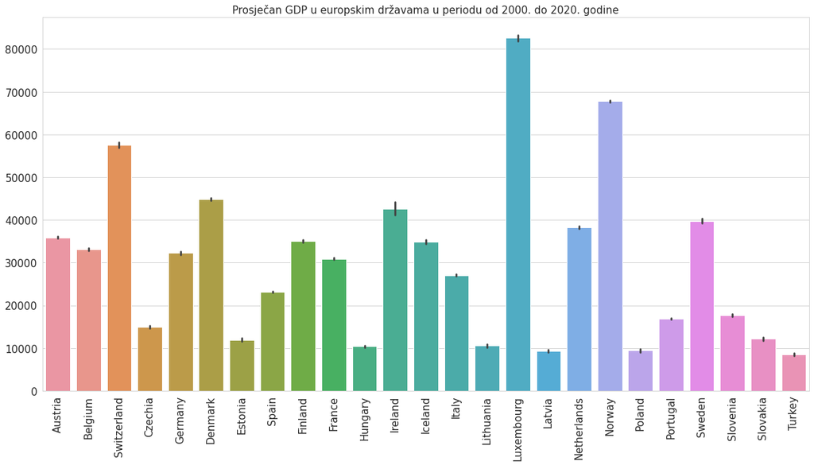

```python
plt.figure(figsize = (20,10))
sns.barplot(x = 'drzava', y = 'gdp', data = podaci)
plt.title("Prosječan GDP u europskim državama u periodu od 2000. do 2020. godine", size = 15)
plt.xticks(size = 15, rotation=90)
plt.yticks(size = 15)
plt.xlabel(None)
plt.ylabel(None)
plt.show()
```

```python
import numpy as np
```

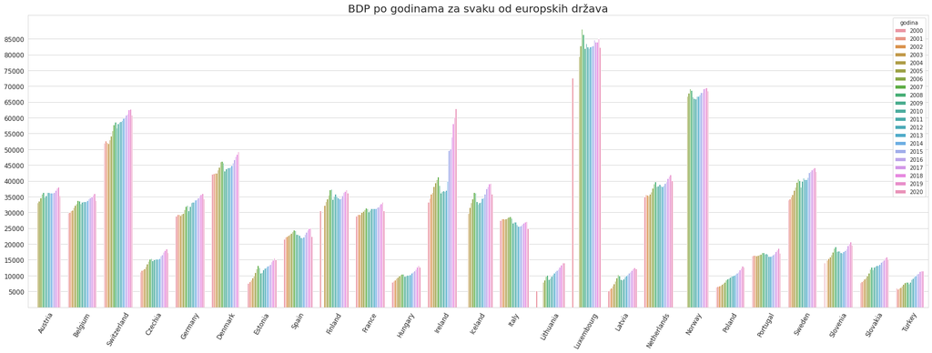

```python
plt.figure(figsize = (30,10))
graf = sns.barplot(x = 'drzava', y = 'gdp', hue = 'godina', data = podaci)
plt.title("BDP po godinama za svaku od europskih država", size = 20)
plt.xticks(size = 12, rotation=60)
plt.yticks(np.arange(min(gdp)-230, max(gdp)+229, 5000),size = 12)
plt.xlabel(None)
plt.ylabel(None)
plt.show()
```

Treća vizualizacija predstavlja postotak stanovništva po grupama tercijarnog obrazovanja za svaku od europskih država.

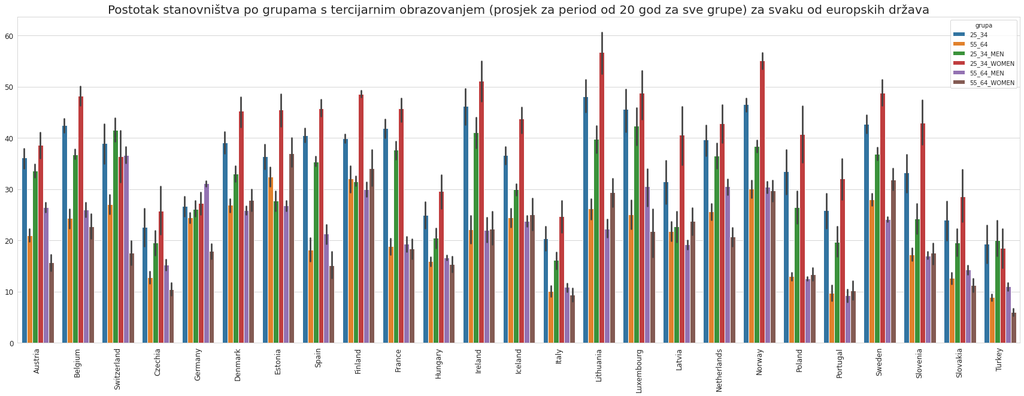

```python
plt.figure(figsize = (30,10))
graf = sns.barplot(x = 'drzava', y = 'postotak', hue = 'grupa', data = podaci)
plt.title("Postotak stanovništva po grupama s tercijarnim obrazovanjem (prosjek za period od 20 god za sve grupe) za svaku od europskih država", size = 20)
plt.xticks(size = 12, rotation=90)
plt.yticks(size = 12)
plt.xlabel(None)
plt.ylabel(None)
plt.show()
```

Četvrta vizualizacija prikazuje prosječan GDP za svaku od 25 europskih država, a na kraju je prikazan i europski prosjek kako bi se moglo vidjeti koje države imaju GDP iznad ili ispod prosjeka.

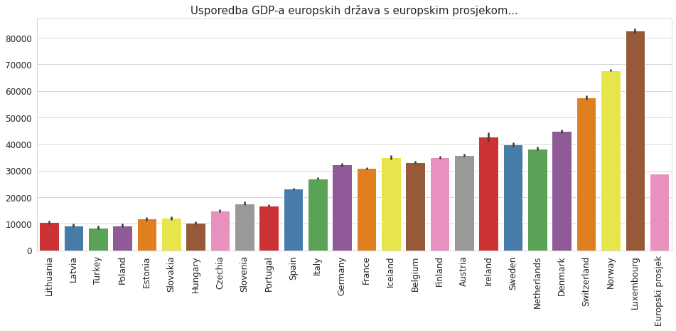

```python
fig, ax = plt.subplots(figsize=(16,6))
najveci_gdp = podaci.sort_values('gdp',ascending=True)
prosjecan_gdp = pd.DataFrame({'drzava':['Europski prosjek'], 'gdp':[podaci['gdp'].mean()]})
gdps = pd.concat([najveci_gdp[['drzava','gdp']],prosjecan_gdp],ignore_index=True)

sns.barplot(x='drzava',y='gdp',data=gdps, palette='Set1')
ax.set_xlabel(ax.get_xlabel(),labelpad=15)
ax.set_ylabel(ax.get_ylabel(),labelpad=30)
plt.title("Usporedba GDP-a europskih država s europskim prosjekom...", size=15)
plt.xticks(size = 12, rotation=90)
plt.yticks(size = 12)
plt.xlabel(None)
plt.ylabel(None)
plt.show()
```

Peta vizualizacija prikazuje točkasti graf zasebno za svaku od 25 država. Prikazuje se postotak stanovništva s tercijarnim obrazovanjem za svaku od promatranih 6 grupa stanovništva za period od 2000. do 2020. godine.

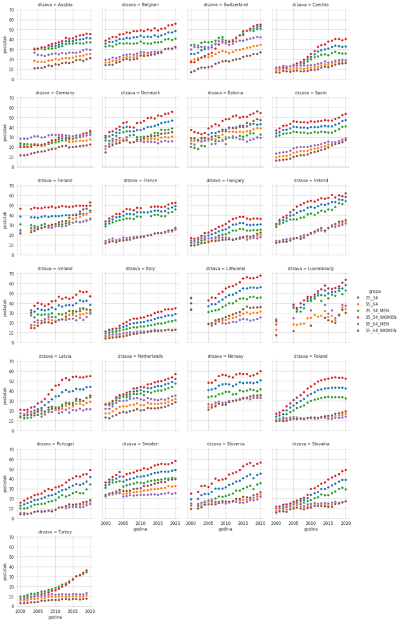

```python
g = sns.FacetGrid(podaci, col='drzava', hue='grupa',col_wrap=4, height=3)
g.map(sns.scatterplot, 'godina', 'postotak', edgecolor="w").add_legend()
plt.show()
```

Šesta vizualizacija prikazuje lineplot ukupnog prosječnog udjela stanovništva s tercijarnim obrazovanjem po godinama...

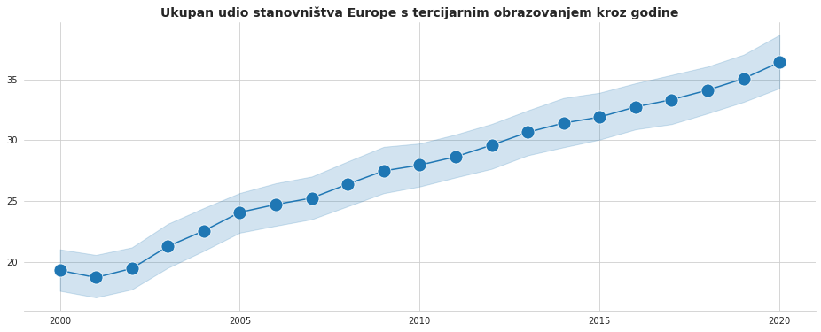

```python
plt.figure(figsize=(16, 6))
sns.lineplot(x='godina', y='postotak', data=podaci, marker='o', markersize=15)
sns.set_style('whitegrid')
sns.despine(left=True)
plt.xticks(np.arange(min(godina), max(godina)+1, 5.0))
plt.title('Ukupan udio stanovništva Europe s tercijarnim obrazovanjem kroz godine', fontsize=14, fontweight='bold')
plt.xlabel(None)
plt.ylabel(None)
plt.show()
```

Sedma vizualizacija prikazuje kretanje GDP-a po godinama za Sloveniju, Poljsku i Irsku, a također i postotni rast GDP-a po godinama za navedene države.

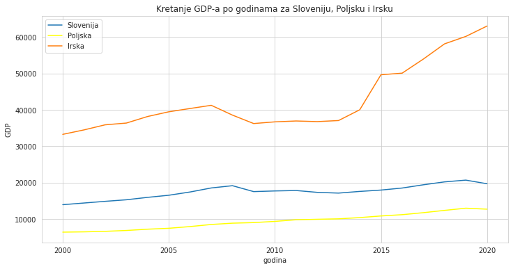

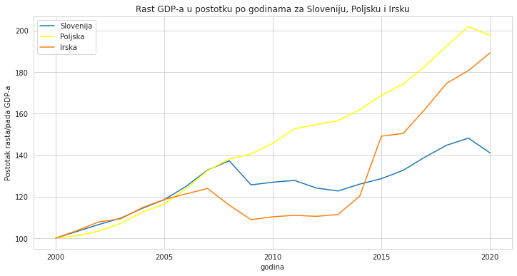

```python
slovenija = podaci[podaci.drzava == 'Slovenia']
poljska = podaci[podaci.drzava == 'Poland']
irska = podaci[podaci.drzava == 'Ireland']

plt.figure(figsize=(12, 6))
plt.title('Kretanje GDP-a po godinama za Sloveniju, Poljsku i Irsku')
plt.plot(slovenija.godina, slovenija.gdp)
plt.plot(poljska.godina, poljska.gdp, color="yellow")
plt.plot(irska.godina, irska.gdp)

plt.legend(['Slovenija', 'Poljska','Irska'])
plt.xlabel('godina')
plt.ylabel('GDP')
plt.xticks(np.arange(min(godina), max(godina)+1, 5.0))
plt.show()

rast_slovenija = slovenija.gdp / slovenija.gdp.iloc[0] * 100
rast_poljska = poljska.gdp / poljska.gdp.iloc[0] * 100
rast_irska = irska.gdp / irska.gdp.iloc[0] * 100

plt.figure(figsize=(12, 6))
plt.title('Rast GDP-a u postotku po godinama za Sloveniju, Poljsku i Irsku')
plt.plot(slovenija.godina, rast_slovenija)
plt.plot(poljska.godina, rast_poljska, color="yellow")
plt.plot(irska.godina, rast_irska)
plt.legend(['Slovenija', 'Poljska','Irska'])
plt.xlabel('godina')
plt.ylabel('Postotak rasta/pada GDP-a')
plt.xticks(np.arange(min(godina), max(godina)+1, 5.0))
plt.show()
```

Osma vizualizacija predstavlja usporedbu GDP-a i postotka muškaraca tercijarne naobrazbe starosti od 25 do 34 godine. Podaci su za 2019. godinu i prikazuju situaciju za sve države.

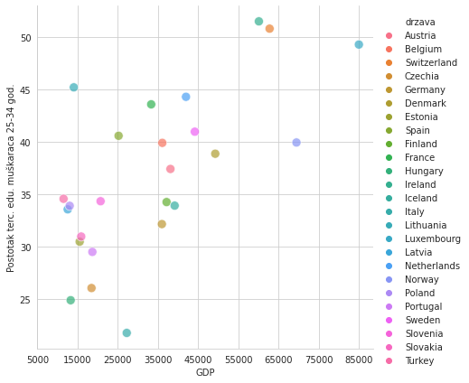

```python
plot = sns.relplot(data=podaci2, x='gdp', y='postotak', hue='drzava', alpha=0.7, edgecolors="grey", height=6, s=100)
plt.xticks(np.arange(min(gdp)-230, max(gdp)+229, 10000))
plot.set_axis_labels("GDP", "Postotak terc. edu. muškaraca 25-34 god.")
plt.show()
```

Deveta vizualizacija prikazuje grafove za svaku državu, a prikazani su odnos GDP-a i postotka žena s tercijarnom razinom obrazovanja u periodu od 2000. do 2020. godine.

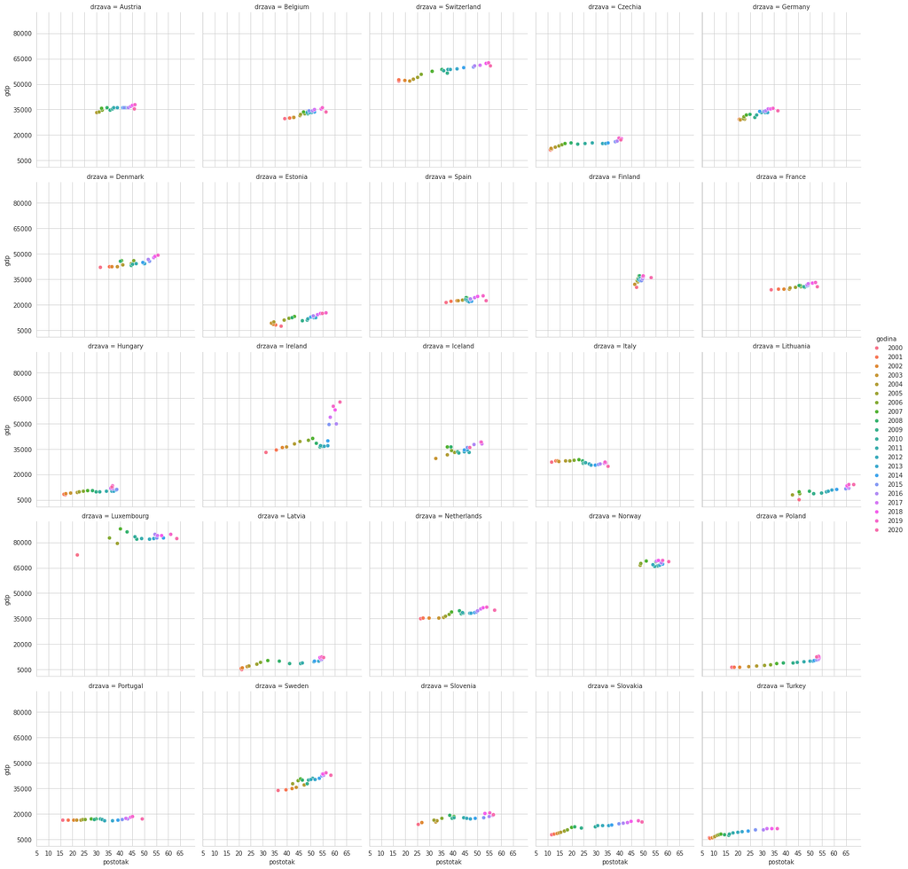

```python
g = sns.FacetGrid(gr25_34w, col='drzava',hue='godina', col_wrap=5, height=4)
g.map(sns.scatterplot, 'postotak', 'gdp', edgecolor="w", s=40).add_legend()
plt.yticks(np.arange(min(gdp)-230, max(gdp)+229, 15000))
plt.xticks(np.arange(min(postotak)+1.81, max(postotak)+1.81, 5))
plt.show()
```

Deseta, posljednja vizualizacija je tzv. violin plot. Ovdje jasno možemo vidjeti koji je prosjek GDP-a za svaku državu u periodu od 2000. do 2020. godine, a vide se i znatnija odstupanja od prosjeka. Što je vrat veći prema gore ili dolje, to je odstupanje od prosjeka veće. Rezultati su prikazani za muškarce od 25-34 godine.

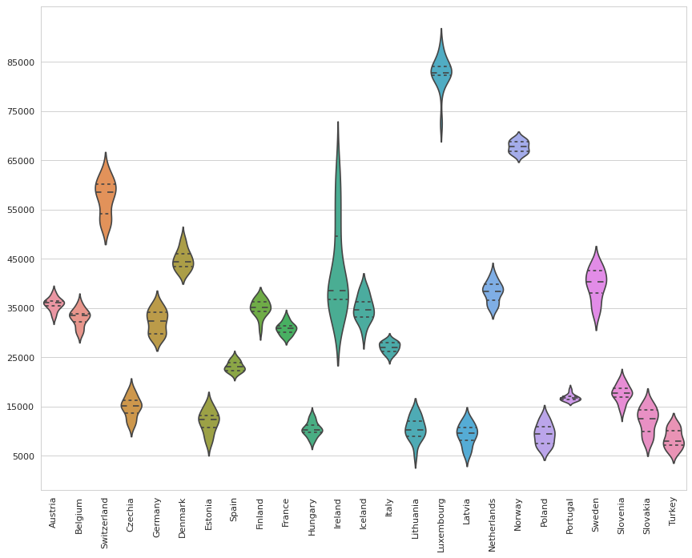

```python
plt.figure(figsize=(13,10), dpi= 80)
sns.violinplot(x='drzava', y='gdp', data=gr25_34m, scale='width', inner='quartile')
plt.xticks(rotation=90)
plt.yticks(np.arange(min(gdp)-230, max(gdp)+229, 10000))
plt.xlabel(None)
plt.ylabel(None)
plt.show()
```